# R Notebook

```r
library(httr)
library(jsonlite)
library(dotenv)
library(ggplot2)
library(stringr)
library(spacyr)
library(dplyr)
# HuggingFace API key needs to be defined as API_KEY in .env
load_dot_env()
wd <- "/Users/tspri/Documents/COGS307"
setwd(wd)
```

## Setup

### Utility methods

Entropy for type and token frequencies

```r
entropy <- function(counts) {
  perc <- counts$n / sum(counts$n)
  # Compute Hnorm
  Hnorm <- -sum(perc * log2(perc)) / log2(length(counts))
  return(Hnorm/10)
}
```

Get type and token frequencies

```r
tt_freqs <- function(df) {
  df_count <- df %>%
    count(lemma, sort=TRUE)
  type_freq <- nrow(df_count)
  token_freq <- sum(df_count$n)
  df_entropy <- entropy(df_count)
  ratio <- type_freq / token_freq
  return(data.frame(type_f=type_freq,token_f=token_freq,tt_ratio=ratio,entropy=df_entropy))
}
```

Type and token frequencies for regular and irregular past tense forms. ‘ed’ stands for ‘-ed’ since all regular past tense forms end with ‘-ed’

```r
ed_type_token <- function(past_verbs) {
  ed_verbs <- past_verbs %>%
    filter(grepl("ed$", token))
  print(ed_verbs)
  ed_ratio <- (count(ed_verbs) / count(past_verbs))$n
  ed_df <- tt_freqs(ed_verbs)
  ed_df$ed_ratio <- ed_ratio
  return(ed_df)
}
```

```r
non_ed_type_token <- function(past_verbs) {
  non_ed_verbs <- past_verbs %>%
    filter(!grepl("ed$", token))
  #print(ed_verbs)
  non_ed_ratio <- (count(non_ed_verbs) / count(past_verbs))$n
  non_ed_df <- tt_freqs(non_ed_verbs)
  non_ed_df$non_ed_ratio <- non_ed_ratio
  return(non_ed_df)
}
```

Segmenting past tense verb information, from a list of verbs

```r
past_tense_seg <- function(verbs) {
  past_tense_verbs <- verbs %>%
    filter(tag == "VBN" | tag == "VBD") %>%
    mutate(ends_with_ed = grepl("ed$", token))
  past_count <- past_tense_verbs %>%
    count(lemma, sort=TRUE)
  ed_values <- ed_type_token(past_tense_verbs)
  print(count(past_tense_verbs))
  print(count(verbs))
  ed_values$past_ratio <- (count(past_tense_verbs) / count(verbs))$n
  return(ed_values)
}
```

Sentence segmentation using HuggingFace model and further cleaning of that model

```r
add_punctuation <- function(input_text) {
  # Load API key from .env file
  api_key <- Sys.getenv("API_KEY")
  # Define API endpoint and headers
  api_url <- "https://api-inference.huggingface.co/models/oliverguhr/fullstop-punctuation-multilang-large"
  headers <- add_headers(Authorization = paste("Bearer", api_key))

  # Define payload as a list
  payload <- list(inputs = input_text)

  # Make POST request and return result
  response <- POST(api_url, headers = headers, body = toJSON(payload))
  result <- content(response, as = "text")
  json_str <- result[[1]]
  # Remove the escaped quotes to make the string valid JSON
  json_str <- gsub('\\"', '"', json_str, fixed = TRUE)
  # Parse the JSON into a data frame
  output <- fromJSON(json_str)[1]
  return(parse_output(output[1]))
}
parse_output <- function(output) {
  df <- data.frame(text = sapply(output, function(x) x$word), entity = sapply(output, function(x) ifelse(x$entity_group == "0", "", x$entity_group)))
  output$word_entity <- paste(output$word, ifelse(output$entity_group == "0", "", output$entity_group), sep = "")
  df$word_entity <- paste(df$text, ifelse(df$entity != "", df$entity, ""), sep="")
  result <- paste(df$word_entity, collapse = " ")
  return(result)
}
```

Getting the parts of speech from a list of lines of text using Spacy

```r
pos_spacy <- function(lines) {
  spacy_initialize(model = "en_core_web_md")
  sentences <- spacy_parse(parsed_lines, "sentencizer",pos=TRUE, tag=TRUE, lemma=TRUE,entity=FALSE, dependency=TRUE, nounphrase=TRUE)
  df <- as.data.frame(sentences)
  parsed_text <- sentences
  pos <- df$pos
  tokens <- df$lemma
  return(df)
}
```

Initial data stored for every data source

```r
further_parsing <- function(parsed_lines) {
  df <- pos_spacy(parsed_lines)
  num_words <- nrow(df)
  num_utterances <- length(unique(df$sentence))
  df_count <- df %>%
    count(lemma, sort=TRUE)
  word_type_freq <- nrow(df_count)
  word_token_freq <- sum(df_count$n)
  mlu <- num_words / num_utterances
  new_df <- data.frame(
    link, video_name, file_name, viewcount, length_in_secs, metadata, programmed, educational, youtubekids, live,
    type_frequency=c(word_type_freq), token_frequency=c(word_token_freq),num_utterances,mlu, output_file_name
  )
  current_data <- adding_info(new_df)
  saveRDS(df, file=output_file_name)
  return(current_data)
}
```

Further analyzing the parts of speech to get transitive verbs, intransitive verbs, nouns and verbs

```r
pos_list <- function(df) {
  all_verbs <- df %>%
    mutate(next_pos = lead(pos),
           next_word = lead(lemma),
           next_pos2 = lead(pos, n = 2),
           next_word2 = lead(lemma, n = 2),
           next_pos3 = lead(pos, n = 3),
           next_word3 = lead(lemma, n = 3)) %>%
    filter(pos %in% c("VERB"))
  #verb_freqs <- tt_freqs(all_verbs)
  #verb_past_tense <- past_tense_seg(all_verbs)
  all_nouns <- df %>%
    filter(pos %in% c("NOUN", "PRON"))
  transitive_verbs <- all_verbs %>%
    filter(lemma != 's') %>%
    filter(next_pos %in% c("NOUN", "PRON") |
             (next_pos == "DET" & next_pos2 == "NOUN") |
             (next_pos == "ADJ" & next_pos2 == "NOUN") |
             (next_pos == "DET" & next_pos2 == "ADJ" & next_pos3 == "NOUN"))
  intransitive_verbs <- all_verbs %>%
    filter(!(next_pos %in% c("NOUN", "PRON") |
               (next_pos == "DET" & next_pos2 == "NOUN") |
               (next_pos == "ADJ" & next_pos2 == "NOUN") |
               (next_pos == "DET" & next_pos2 == "ADJ" & next_pos3 == "NOUN")))
  return(list(tv=transitive_verbs, iv=intransitive_verbs, av=all_verbs, an=all_nouns))
}
```

Adding new information to the main Rda file

```r
adding_info <- function(df, full_file="youtube.Rda") {
  if(file.exists(full_file)) {
    olddata <- readRDS(file=full_file)
    new_df <- rbind(df, olddata)
    saveRDS(new_df,file=full_file)
  }
  else {
    saveRDS(df, file=full_file)
  }
  current_data <- readRDS(file=full_file)
  return(current_data)
}
update_info <- function(df, val, curr="ryan.vtt", full_file="youtube.Rda") {
  row_index <- which(df$file_name == curr)
  df[row_index, "mlu"] <- val
  saveRDS(df, file=full_file)
  return(df)
}
```

Cleaning the input data from CHILDES

```r
parse_mot_data <- function(lines) {
  results <- list()
  in_mot <- FALSE
  mot_text <- ""
  for (line in lines) {
    if (startsWith(line, "*CHI")) {
      in_mot <- TRUE
      mot_text <- paste(mot_text, str_replace(line, "^\\*CHI:\\s+", ""))
    }
    else if (startsWith(line, "*") || startsWith(line, "%")) {
      in_mot <- FALSE
    }
    else if (in_mot) {
      mot_text <- paste(mot_text, line)
    }
  }
  mot_text <- str_replace_all(mot_text, "@g", "")
  mot_text <- gsub("[^[:alnum:][:space:]?!.]", "", mot_text)
  return(mot_text)
}
```

Cleaning the input data from YouTube captions. good_cc_parsing accounts for actual captions that are formatted differently than the automated ones

```r
parse_vtt_w_punctuation <- function(input_text) {
  indices <- grep("<c>", input_text)
  spoken_lines <- gsub("<[^>]+>", "", input_text[indices])
  pasted_lines <- paste(spoken_lines, collapse=" ")
  if (length(pasted_lines) <= 1) {
    pasted_lines = good_cc_parsing(input_text)
  }
  punctuated_lines <- add_punctuation(pasted_lines)
  return(punctuated_lines)
}
good_cc_parsing <- function(input_text) {
  modified_text <- ""
  # loop through each line of the input text
  for (i in seq_along(input_text)) {

    # check if the line starts with a timestamp
    if (grepl("^\\d{2}:\\d{2}:\\d{2}.\\d{3}", input_text[i])) {

      # if the line starts with a timestamp, skip it and the next line
      i <- i + 1

    } else {
      input_text[i] = gsub('"', '', input_text[i])
      # if the line does not start with a timestamp, check if it starts with a narrator's name
      if (grepl("^\\w+:", input_text[i])) {

        # if the line starts with a narrator's name, remove it
        modified_text <- paste(modified_text, sub("^\\w+:\\s*", "", input_text[i]))

      } else {
        # if the line does not start with a narrator's name, append it to the modified text
        modified_text <- paste(modified_text, input_text[i])
      }

    }

  }
  return(modified_text)
}
```

Util method used to merge frames. Initial versions of frames did not include information so this had to be used.

```r
mergeFrames <- function(df, final_file="youtube.Rda") {
  df1 <- readRDS(file=final_file)
  df2 <- df
  commonNames <- names(df1)[which(colnames(df1) %in% colnames(df2))]
  commonNames <- commonNames[commonNames != "file_name"]
  dfmerge<- merge(df1,df2,by="file_name",all=T)
  for(i in commonNames){
    left <- paste(i, ".x", sep="")
    right <- paste(i, ".y", sep="")
    dfmerge[is.na(dfmerge[left]),left] <- dfmerge[is.na(dfmerge[left]),right]
    dfmerge[right]<- NULL
    colnames(dfmerge)[colnames(dfmerge) == left] <- i
  }
  saveRDS(dfmerge, file=final_file)
  return(readRDS(file=final_file))
}
```

This was a use-case for the mergeFrames method above

```r
file_name <- "Nadig/135.cha"
output_file_name <- "135.Rda"
new_df <- data.frame(
  file_name, output_file_name, link="N/A")
new_df <- mergeFrames(new_df)
```

Quick util for when the last column added is incorrect

```r
remove_last_column <- function() {
  current_data <- readRDS("youtube.Rda")
  current_data <- current_data[-c(1),]
  saveRDS(current_data, "youtube.Rda")
}
```

```r
plot_distribution <- function(top_words, name) {
  # Create a bar graph of the top 25 words
  ggplot(top_words, aes(x = reorder(lemma, -n), y = n)) +
  geom_bar(stat = "identity", fill = "steelblue") +
  xlab("Word") +
  ylab("Frequency") +
  theme(axis.text.y = element_text(size = 10)) +
  theme(axis.text.x = element_text(size = 5)) +
  ggtitle(name)
}
```

### Workflow

Below is the process followed to add every file to the dataframe.  
The following text is changed and is the basis of every video/transcript added.

```r
output_file_name <- "cocomelon2.Rda"
file_name <- "cocomelon2.vtt"
video_name <- "You Can Ride a Bike Song ｜ @CoComelon & Kids Songs ｜ Learning Videos For Toddlers"
viewcount <- 154000000
link <- "https://www.youtube.com/watch?v=zj3UYhSsrwU"
programmed <- TRUE
youtubekids <- TRUE
educational <- TRUE
live <- FALSE
length_in_secs <- 2040
metadata <- ""
```

```r
add_file_info <- function () {
  lines <- readLines(file_name)
  # If it is a video and not a transcript
  if (viewcount > 0) {
    parsed_lines <- parse_vtt_w_punctuation(lines)
  } else {
    parsed_lines <- parse_mot_data(lines)
  }
  current_data <- further_parsing(parsed_lines)
  return(current_data)
}
#df <- pos_spacy(parsed_lines)
#saveRDS(df, file=output_file_name)
```

```r
current_data <- readRDS(file="youtube.Rda")
current_data
```

| file_name | link | video_name | viewcount | length_in_secs | metadata | programmed | educational | youtubekids | live | type_frequency | token_frequency | num_utterances | mlu | output_file_name |
| --- | --- | --- | --- | --- | --- | --- | --- | --- | --- | --- | --- | --- | --- | --- |
| beast.vtt | https://www.youtube.com/watch?v=LeYsRMZFUq0 | I Gave People $1,000,000 But ONLY 1 Minute To Spend It! | 1.54e+08 | 840 |  | FALSE | FALSE | FALSE | TRUE | 162 | 506 | 57 | 8.877193 | beast1.Rda |
| blippi.vtt | https://www.youtube.com/watch?v=-n8J4sh0mTA | Blippi and Meekah's Colorful Earth Day Challenge! Educational Videos for Kids | 4.72e+05 | 896 |  | FALSE | TRUE | TRUE | TRUE | 165 | 528 | 58 | 9.103448 | blippi1.Rda |
| cocomelon.vtt | https://www.youtube.com/watch?v=WM4ys_PnrUY | Ten Little Duckies \| @CoComelon Learning Videos | 1.75e+08 | 1920 |  | TRUE | TRUE | TRUE | FALSE | 98 | 521 | 40 | 13.025000 | cocomelon1.Rda |
| cocomelon2.vtt | https://www.youtube.com/watch?v=zj3UYhSsrwU | You Can Ride a Bike Song ｜ @CoComelon & Kids Songs ｜ Learning Videos For Toddlers | 1.54e+08 | 2040 |  | TRUE | TRUE | TRUE | FALSE | 64 | 274 | 43 | 6.372093 | cocomelon2.Rda |
| diana.vtt | https://www.youtube.com/watch?v=PsLpYsCwv_I | Diana and Roma - mysterious challenge in the house | 9.50e+08 | 450 |  | FALSE | FALSE | FALSE | FALSE | 11 | 18 | 4 | 4.500000 | diana1.Rda |
| mickey.vtt | https://www.youtube.com/watch?v=GZcmKNDgf8I | Mickey's Color Adventure \| S1 E22 \| Full Episode \| Mickey Mouse Clubhouse | 3.40e+07 | 1440 |  | TRUE | FALSE | TRUE | FALSE | 135 | 351 | 55 | 6.381818 | mickey1.Rda |
| mickey2.vtt | https://www.youtube.com/watch?v=m3LV5Z2nCRg | Mickey Goes Fishing \| S1 E5 \| Full Episode \| Mickey Mouse Clubhouse | 2.70e+07 | 1440 |  | TRUE | FALSE | TRUE | FALSE | 67 | 155 | 10 | 15.500000 | mickey2.Rda |
| Nadig/102.cha | N/A | 4 years old | 0.00e+00 | 0 | Parent education: Below university, ASD | FALSE | FALSE | FALSE | NA | 218 | 1639 | 319 | 5.137931 | 102.Rda |
| Nadig/103.cha | N/A | 2 and a half years old | 0.00e+00 | 0 | Parent education: Below university, TYP | FALSE | FALSE | FALSE | NA | 231 | 1042 | 170 | 6.129412 | 103.Rda |
| Nadig/104.cha | N/A | 3 and a half years old | 0.00e+00 | 0 | Parent education: University | FALSE | FALSE | FALSE | NA | 190 | 966 | 217 | 4.451613 | 104.Rda |

[output cut: 9 more lines]

## Data analysis

The main category for data analysis was direct comparison of YouTube Kids to maternal input. Further categories included comparing educational videos to non-educational ones and comparing programmed videos to non-programmed ones. The data pipeline is set up in a way where it can be extended to look at live videos vs non-live videos and add other input sources such as YouTube or a TV show.

```r
df <- readRDS(file="youtube.Rda")
df_filtered <- subset(df, !(grepl("output", video_name) | (youtubekids == FALSE & viewcount > 0)))
```

### Video accuracy

The video that was manually assessed for accuracy was Ryan’s Mystery Playdate Episode 1 for international RTR Fans.

```r
ryan_vid <- readRDS(df_filtered[c(9),]$output_file_name)
wrong_tokens <- 11
right_tokens <- count(ryan_vid)$n - wrong_tokens
missing_tokens <- 22
right_sentence_segmentations <- 51
# Sentence segmentation too late
fwd_sentence_segmentations <- 13
# Sentence segmentation too early
back_sentence_seg <- 3
total_sentences <- df_filtered[c(9),]$num_utterances
new_sentences <- total_sentences + fwd_sentence_segmentations - back_sentence_seg
total_tokens <- df_filtered[c(9),]$token_frequency
new_total_tokens <- total_tokens + missing_tokens
orig_mlu <- df_filtered[c(9),]$mlu
new_mlu <- new_total_tokens / new_sentences
```

Precision and recall calculations

```r
TP_sent <- right_sentence_segmentations
FP_sent <- fwd_sentence_segmentations + back_sentence_seg
FN_sent <- total_sentences - TP_sent

precision_sent <- TP_sent / (TP_sent + FP_sent)
recall_sent <- TP_sent / (TP_sent + FN_sent)

# Token recognition
TP_token <- right_tokens
FP_token <- wrong_tokens
FN_token <- new_total_tokens - TP_token

precision_token <- TP_token / (TP_token + FP_token)
recall_token <- TP_token / (TP_token + FN_token)
```

Accuracy table

```r
df <- data.frame(
  word_precision=precision_token,
  word_recall=recall_token,
  sentence_precision=precision_sent,
  sentence_recall=recall_sent,
  original_mlu = orig_mlu,
  new_mlu = new_mlu
)

# Print the data frame
df
```

| word_precision | word_recall | sentence_precision | sentence_recall | original_mlu | new_mlu |
| --- | --- | --- | --- | --- | --- |
| 0.9902655 | 0.9713542 | 0.761194 | 0.2947977 | 6.531792 | 6.295082 |

### Mean lengths of utterances

```r
# calculate weighted mean length of utterance by youtubekids
mlu_table <- aggregate(df_filtered[,c("mlu","num_utterances")], by=list(df_filtered$youtubekids), FUN=function(x) sum(x[1]*x[2])/sum(x[2]))

# add column names to the table
colnames(mlu_table) <- c("youtubekids", "mlu")

# print the table
print(mlu_table)
```

| youtubekids | mlu | None |
| --- | --- | --- |
| FALSE | 5.137931 | 319 |
| TRUE | 9.103448 | 58 |

### Datasets

```r
df_youtubekids <- subset(df_filtered, (youtubekids == TRUE))
df_maternal <- subset(df_filtered, (youtubekids == FALSE))
df_programmed <- subset(df_youtubekids, (programmed == TRUE))
df_nonprogrammed <- subset(df_youtubekids, (programmed == FALSE))
df_educational <- subset(df_youtubekids, (educational == TRUE))
df_uneducational <- subset(df_youtubekids, (educational == FALSE))
```

Get the aggregated list of tokens with part of speech tags

```r
combined <- function(df) {
  df_list <- lapply(df$output_file_name, function(name) {
  readRDS(name)
})
  # Use do.call() to combine the data frames into a single data frame
  combined_list <- do.call(rbind, df_list)
  return(combined_list)
}
youtubekids_data <- combined(df_youtubekids)
maternal_data <- combined(df_maternal)
yk_pos <- pos_list(youtubekids_data)
m_pos <- pos_list(maternal_data)
prog_pos <- pos_list(combined(df_programmed))
nonprog_pos <- pos_list(combined(df_nonprogrammed))
edu_pos <- pos_list(combined(df_educational))
nonedu_pos <- pos_list(combined(df_uneducational))
```

### Verbs and nouns

#### Type and token frequency

```r
yk_freqs <- tt_freqs(yk_pos$av)
m_freqs <- tt_freqs(m_pos$av)
yk_freqs_nouns <- tt_freqs(yk_pos$an)
m_freqs_nouns <- tt_freqs(m_pos$an)
nv <- data.frame(verbs=rbind(yk_freqs, m_freqs), nouns=rbind(yk_freqs_nouns, m_freqs_nouns))
rownames(nv) <- c("YouTube Kids", "Maternal Input")
nv
```

|  | verbs.type_f | verbs.token_f | verbs.tt_ratio | verbs.entropy | nouns.type_f | nouns.token_f | nouns.tt_ratio | nouns.entropy |
| --- | --- | --- | --- | --- | --- | --- | --- | --- |
| YouTube Kids | 85 | 266 | 0.3195489 | 0.5617073 | 158 | 577 | 0.2738302 | 0.6090798 |
| Maternal Input | 137 | 956 | 0.1433054 | 0.5836930 | 249 | 1631 | 0.1526671 | 0.6193445 |

### Transitive and intransitive verbs

#### Type and token frequency

```r
yk_freqs <- tt_freqs(yk_pos$tv)
m_freqs <- tt_freqs(m_pos$tv)
yk_freqs_iv <- tt_freqs(yk_pos$iv)
m_freqs_iv <- tt_freqs(m_pos$iv)
edu_pos <- pos_list(combined(df_educational))
nonedu_pos <- pos_list(combined(df_uneducational))
ti <- data.frame(transitive=rbind(yk_freqs, m_freqs, tt_freqs(prog_pos$tv), tt_freqs(nonprog_pos$tv), tt_freqs(edu_pos$tv), tt_freqs(nonedu_pos$tv)), intransitive=rbind(yk_freqs_iv, m_freqs_iv, tt_freqs(prog_pos$iv), tt_freqs(nonprog_pos$iv), tt_freqs(edu_pos$iv), tt_freqs(nonedu_pos$iv)))
rownames(ti) <- c("YouTube Kids", "Maternal Input", "Programmed", "Non-programmed", "Educational", "Non-educational")
ti
```

|  | transitive.type_f | transitive.token_f | transitive.tt_ratio | transitive.entropy | intransitive.type_f | intransitive.token_f | intransitive.tt_ratio | intransitive.entropy |
| --- | --- | --- | --- | --- | --- | --- | --- | --- |
| YouTube Kids | 47 | 99 | 0.4747475 | 0.5165035 | 56 | 167 | 0.3353293 | 0.4973170 |
| Maternal Input | 89 | 378 | 0.2354497 | 0.5533670 | 89 | 549 | 0.1621129 | 0.5239028 |
| Programmed | 13 | 29 | 0.4482759 | 0.3436626 | 25 | 82 | 0.3048780 | 0.4048672 |
| Non-programmed | 37 | 70 | 0.5285714 | 0.4864947 | 39 | 85 | 0.4588235 | 0.4646690 |
| Educational | 24 | 41 | 0.5853659 | 0.4235210 | 39 | 103 | 0.3786408 | 0.4592288 |
| Non-educational | 32 | 58 | 0.5517241 | 0.4694019 | 30 | 64 | 0.4687500 | 0.4318392 |

Slightly higher entropy with maternal input and much lower ratio  
Programmed content seems to have a much lower entropy

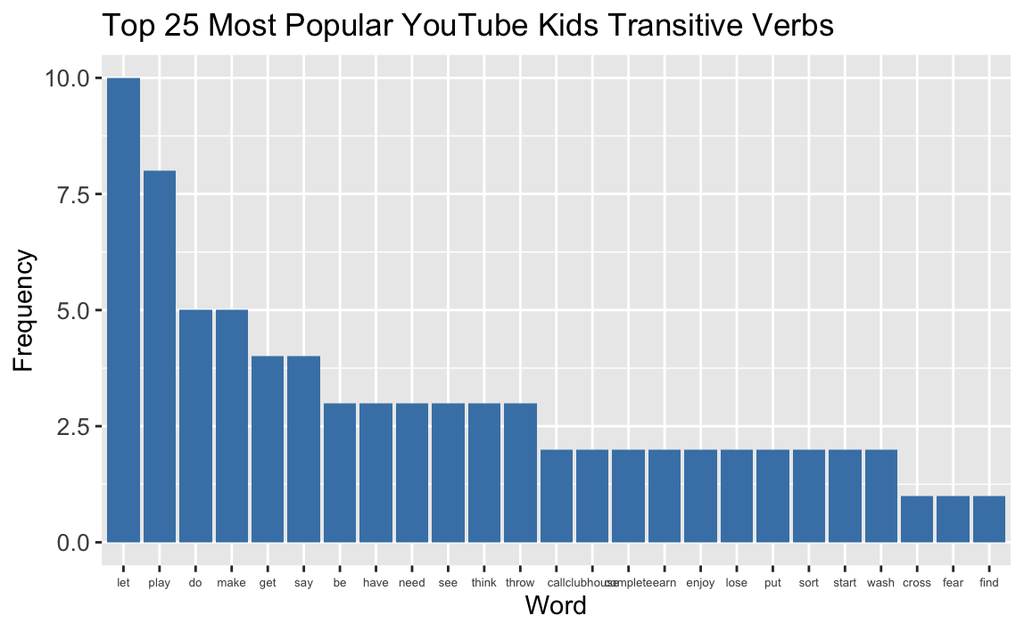

```r
yktv_df <- yk_pos$tv %>%
    count(lemma, sort=TRUE)
top_words <- yktv_df[order(-yktv_df$n),][1:25,]

# Create a bar graph of the top 25 words
plot_distribution(top_words, "Top 25 Most Popular YouTube Kids Transitive Verbs")
```

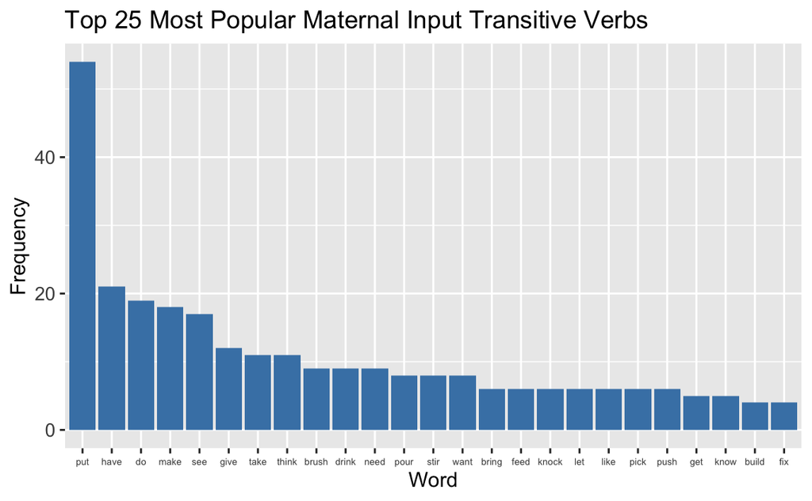

```r
mtv_df <- m_pos$tv %>%
    count(lemma, sort=TRUE)
top_words <- mtv_df[order(-mtv_df$n),][1:25,]

# Create a bar graph of the top 25 words
plot_distribution(top_words, "Top 25 Most Popular Maternal Input Transitive Verbs")
```

#### Collostructional analysis

Collostructional analysis was used to measure the verb-transitive contingency, the strength of a verb being present in a transitive slot

Flach, Susanne. 2021. *Collostructions: An R implementation for the family of collostructional methods*. Package version v.0.2.0, https://sfla.ch/collostructions/.

```r
install.packages(file.choose(), repos = NULL)
library(collostructions)
```

Formatting data to be accepted by collostructional parser

```r
yk_counts <- youtubekids_data %>%
    count(lemma, sort=TRUE)
m_counts <- maternal_data %>%
    count(lemma, sort=TRUE)
yk_counts <- subset(yk_counts, lemma %in% m_counts$lemma)
m_counts <- subset(m_counts, lemma %in% yk_counts$lemma)
colnames(yk_counts)[2] <- "CORP.FREQ"
colnames(yktv_df)[2] <- "CXN.FREQ"
c_yk <- merge(yk_counts, yktv_df, by="lemma")
c_yk_all <- data.frame(WORD=c_yk$lemma, CXN.FREQ=c_yk$CXN.FREQ, CORP.FREQ=c_yk$CORP.FREQ)
```

Running it through

```r
collex(c_yk_all, 2547) -> c_yk_all.out
data.frame(word=c_yk_all.out$COLLEX, observation=c_yk_all.out$OBS, frequency=c_yk_all.out$CORP.FREQ, coll_strength=c_yk_all.out$COLL.STR.LOGL, association=c_yk_all.out$ASSOC, significance=c_yk_all.out$SIGNIF)
```

| word | observation | frequency | coll_strength | association | significance |
| --- | --- | --- | --- | --- | --- |
| let | 10 | 12 | 68.68132 | attr | ***** |
| make | 5 | 8 | 28.73068 | attr | ***** |
| need | 3 | 3 | 23.40385 | attr | ***** |
| think | 3 | 3 | 23.40385 | attr | ***** |
| get | 4 | 8 | 20.34795 | attr | ***** |
| see | 3 | 5 | 16.75317 | attr | **** |
| say | 4 | 12 | 16.31799 | attr | **** |
| do | 5 | 25 | 14.94670 | attr | *** |
| put | 2 | 3 | 11.78580 | attr | *** |
| call | 2 | 4 | 10.10021 | attr | ** |

[output cut: 10 more lines]

```r
colnames(m_counts)[2] <- "CORP.FREQ"
colnames(mtv_df)[2] <- "CXN.FREQ"
c_m <- merge(m_counts, mtv_df, by="lemma")
c_m_all <- data.frame(WORD=c_m$lemma, CXN.FREQ=c_m$CXN.FREQ, CORP.FREQ=c_m$CORP.FREQ)
```

```r
collex(c_m_all, 2547) -> c_m_all.out
data.frame(word=c_m_all.out$COLLEX, observation=c_m_all.out$OBS, frequency=c_m_all.out$CORP.FREQ, coll_strength=c_m_all.out$COLL.STR.LOGL, association=c_m_all.out$ASSOC, significance=c_m_all.out$SIGNIF)
```

| word | observation | frequency | coll_strength | association | significance |
| --- | --- | --- | --- | --- | --- |
| put | 54 | 63 | 236.09200 | attr | ***** |
| make | 18 | 20 | 79.51328 | attr | ***** |
| have | 21 | 28 | 77.45045 | attr | ***** |
| give | 12 | 14 | 49.96544 | attr | ***** |
| see | 17 | 29 | 49.52677 | attr | ***** |
| take | 11 | 14 | 41.91563 | attr | ***** |
| need | 9 | 10 | 39.38222 | attr | ***** |
| think | 11 | 17 | 34.86780 | attr | ***** |
| fix | 4 | 4 | 20.22957 | attr | ***** |
| do | 19 | 94 | 14.43949 | attr | *** |

[output cut: 10 more lines]

### Regular and irregular past tense forms

#### Type and token frequency

```r
yk_freqs <- past_tense_seg(yk_pos$av)
```

| doc_id | sentence_id | token_id | token | lemma | pos | tag | head_token_id | dep_rel | nounphrase | whitespace | next_pos | next_word | next_pos2 | next_word2 | next_pos3 | next_word3 | ends_with_ed |
| --- | --- | --- | --- | --- | --- | --- | --- | --- | --- | --- | --- | --- | --- | --- | --- | --- | --- |
| text1 | 28 | 3 | bloomed | bloom | VERB | VBN | 3 | ROOT |  | TRUE | ADV | yet | PUNCT | . | INTJ | no | TRUE |
| text1 | 43 | 5 | asked | ask | VERB | VBD | 3 | ccomp |  | TRUE | ADV | actually | PUNCT | , | ADP | of | TRUE |
| text1 | 18 | 2 | washed | wash | VERB | VBD | 2 | ROOT |  | TRUE | PRON | their | NOUN | mitten | CCONJ | and | TRUE |
| text1 | 19 | 1 | washed | wash | VERB | VBD | 1 | ROOT |  | TRUE | PRON | your | NOUN | mitt | PUNCT | . | TRUE |
| text1 | 39 | 4 | rolled | roll | VERB | VBD | 4 | ROOT |  | TRUE | ADP | over | CCONJ | and | NUM | one | TRUE |
| text1 | 23 | 6 | earned | earn | VERB | VBN | 6 | ROOT |  | TRUE | PRON | your | ADJ | first | NOUN | hint | TRUE |
| text1 | 33 | 5 | called | call | VERB | VBN | 5 | ROOT |  | TRUE | PRON | who | VERB | let | DET | the | TRUE |
| text1 | 39 | 3 | earned | earn | VERB | VBN | 3 | ROOT |  | TRUE | PRON | your | ADJ | second | NOUN | hint | TRUE |

| n |
| --- |
| 44 |

| n |
| --- |
| 266 |

```r
m_freqs <- past_tense_seg(m_pos$av)
```

| doc_id | sentence_id | token_id | token | lemma | pos | tag | head_token_id | dep_rel | nounphrase | whitespace | next_pos | next_word | next_pos2 | next_word2 | next_pos3 | next_word3 | ends_with_ed |
| --- | --- | --- | --- | --- | --- | --- | --- | --- | --- | --- | --- | --- | --- | --- | --- | --- | --- |
| text1 | 29 | 4 | spilled | spill | VERB | VBD | 4 | ROOT |  | TRUE | DET | the | NOUN | tea | NOUN | uhoh | TRUE |
| text1 | 72 | 5 | answered | answer | VERB | VBD | 3 | relcl |  | TRUE | DET | the | NOUN | phone | PUNCT | . | TRUE |
| text1 | 108 | 2 | happened | happen | VERB | VBD | 2 | ROOT |  | TRUE | PUNCT | ? | PRON | you | VERB | shake | TRUE |
| text1 | 125 | 2 | wanted | want | VERB | VBD | 2 | ROOT |  | TRUE | PART | to | VERB | knock | PRON | it | TRUE |
| text1 | 138 | 2 | knocked | knock | VERB | VBD | 2 | ROOT |  | TRUE | PRON | it | ADP | down | PUNCT | . | TRUE |
| text1 | 52 | 4 | spilled | spill | VERB | VBN | 4 | ROOT |  | TRUE | PUNCT | . | VERB | pick | PRON | it | TRUE |
| text1 | 58 | 4 | spilled | spill | VERB | VBN | 2 | ccomp |  | TRUE | PUNCT | . | INTJ | no | PRON | you | TRUE |
| text1 | 115 | 2 | finished | finish | VERB | VBN | 2 | ROOT |  | TRUE | PUNCT | ? | INTJ | alright | INTJ | okay | TRUE |
| text1 | 80 | 8 | knocked | knock | VERB | VBD | 8 | ROOT |  | TRUE | PRON | it | ADP | over | PUNCT | . | TRUE |
| text1 | 95 | 9 | figured | figure | VERB | VBD | 6 | ccomp |  | TRUE | PRON | that | ADP | out | PUNCT | . | TRUE |

[output cut: 5 more lines]

| n |
| --- |
| 59 |

| n |
| --- |
| 956 |

```r
ti <- data.frame(ed_form=rbind(yk_freqs, m_freqs, past_tense_seg(prog_pos$av), past_tense_seg(nonprog_pos$av), past_tense_seg(edu_pos$av), past_tense_seg(nonedu_pos$av)))
```

| doc_id | sentence_id | token_id | token | lemma | pos | tag | head_token_id | dep_rel | nounphrase | whitespace | next_pos | next_word | next_pos2 | next_word2 | next_pos3 | next_word3 | ends_with_ed |
| --- | --- | --- | --- | --- | --- | --- | --- | --- | --- | --- | --- | --- | --- | --- | --- | --- | --- |
| text1 | 18 | 2 | washed | wash | VERB | VBD | 2 | ROOT |  | TRUE | PRON | their | NOUN | mitten | CCONJ | and | TRUE |
| text1 | 19 | 1 | washed | wash | VERB | VBD | 1 | ROOT |  | TRUE | PRON | your | NOUN | mitt | PUNCT | . | TRUE |
| text1 | 39 | 4 | rolled | roll | VERB | VBD | 4 | ROOT |  | TRUE | ADP | over | CCONJ | and | NUM | one | TRUE |

| n |
| --- |
| 35 |

| n |
| --- |
| 111 |

| doc_id | sentence_id | token_id | token | lemma | pos | tag | head_token_id | dep_rel | nounphrase | whitespace | next_pos | next_word | next_pos2 | next_word2 | next_pos3 | next_word3 | ends_with_ed |
| --- | --- | --- | --- | --- | --- | --- | --- | --- | --- | --- | --- | --- | --- | --- | --- | --- | --- |
| text1 | 28 | 3 | bloomed | bloom | VERB | VBN | 3 | ROOT |  | TRUE | ADV | yet | PUNCT | . | INTJ | no | TRUE |
| text1 | 43 | 5 | asked | ask | VERB | VBD | 3 | ccomp |  | TRUE | ADV | actually | PUNCT | , | ADP | of | TRUE |
| text1 | 23 | 6 | earned | earn | VERB | VBN | 6 | ROOT |  | TRUE | PRON | your | ADJ | first | NOUN | hint | TRUE |
| text1 | 33 | 5 | called | call | VERB | VBN | 5 | ROOT |  | TRUE | PRON | who | VERB | let | DET | the | TRUE |
| text1 | 39 | 3 | earned | earn | VERB | VBN | 3 | ROOT |  | TRUE | PRON | your | ADJ | second | NOUN | hint | TRUE |

| n |
| --- |
| 9 |

| n |
| --- |
| 155 |

| doc_id | sentence_id | token_id | token | lemma | pos | tag | head_token_id | dep_rel | nounphrase | whitespace | next_pos | next_word | next_pos2 | next_word2 | next_pos3 | next_word3 | ends_with_ed |
| --- | --- | --- | --- | --- | --- | --- | --- | --- | --- | --- | --- | --- | --- | --- | --- | --- | --- |
| text1 | 28 | 3 | bloomed | bloom | VERB | VBN | 3 | ROOT |  | TRUE | ADV | yet | PUNCT | . | INTJ | no | TRUE |
| text1 | 43 | 5 | asked | ask | VERB | VBD | 3 | ccomp |  | TRUE | ADV | actually | PUNCT | , | ADP | of | TRUE |
| text1 | 18 | 2 | washed | wash | VERB | VBD | 2 | ROOT |  | TRUE | PRON | their | NOUN | mitten | CCONJ | and | TRUE |
| text1 | 19 | 1 | washed | wash | VERB | VBD | 1 | ROOT |  | TRUE | PRON | your | NOUN | mitt | PUNCT | . | TRUE |
| text1 | 39 | 4 | rolled | roll | VERB | VBD | 4 | ROOT |  | TRUE | ADP | over | CCONJ | and | NUM | one | TRUE |

| n |
| --- |
| 36 |

| n |
| --- |
| 144 |

| doc_id | sentence_id | token_id | token | lemma | pos | tag | head_token_id | dep_rel | nounphrase | whitespace | next_pos | next_word | next_pos2 | next_word2 | next_pos3 | next_word3 | ends_with_ed |
| --- | --- | --- | --- | --- | --- | --- | --- | --- | --- | --- | --- | --- | --- | --- | --- | --- | --- |
| text1 | 23 | 6 | earned | earn | VERB | VBN | 6 | ROOT |  | TRUE | PRON | your | ADJ | first | NOUN | hint | TRUE |
| text1 | 33 | 5 | called | call | VERB | VBN | 5 | ROOT |  | TRUE | PRON | who | VERB | let | DET | the | TRUE |
| text1 | 39 | 3 | earned | earn | VERB | VBN | 3 | ROOT |  | TRUE | PRON | your | ADJ | second | NOUN | hint | TRUE |

| n |
| --- |
| 8 |

| n |
| --- |
| 122 |

```r
rownames(ti) <- c("YouTube Kids", "Maternal Input", "Programmed", "Non-programmed", "Educational", "Non-educational")
ti
```

|  | ed_form.type_f | ed_form.token_f | ed_form.tt_ratio | ed_form.entropy | ed_form.ed_ratio | ed_form.past_ratio |
| --- | --- | --- | --- | --- | --- | --- |
| YouTube Kids | 6 | 8 | 0.7500000 | 0.25000000 | 0.18181818 | 0.16541353 |
| Maternal Input | 10 | 15 | 0.6666667 | 0.31898981 | 0.25423729 | 0.06171548 |
| Programmed | 2 | 3 | 0.6666667 | 0.09182958 | 0.08571429 | 0.31531532 |
| Non-programmed | 4 | 5 | 0.8000000 | 0.19219281 | 0.55555556 | 0.05806452 |
| Educational | 4 | 5 | 0.8000000 | 0.19219281 | 0.13888889 | 0.25000000 |
| Non-educational | 2 | 3 | 0.6666667 | 0.09182958 | 0.37500000 | 0.06557377 |

```r
past_tense_verb_counts <- function(df) {
  verbs <- df$av %>%
    filter(tag == "VBN" | tag == "VBD") %>%
    filter(grepl("ed$", token))
  return(verbs %>%
    count(lemma, sort=TRUE))
}
past_tense_verbs_yk  <- past_tense_verb_counts(yk_pos)
past_tense_verbs <- past_tense_verb_counts(m_pos)
top_words_yk <- past_tense_verbs_yk[order(-past_tense_verbs_yk$n),][1:5,]
top_words_m <- past_tense_verbs [order(-past_tense_verbs$n),][1:5,]
data.frame(maternal_top_words=top_words_m, youtubekids_top_words=top_words_yk)
```

|  | maternal_top_words.lemma | maternal_top_words.n | youtubekids_top_words.lemma | youtubekids_top_words.n |
| --- | --- | --- | --- | --- |
| 1 | spill | 3 | earn | 2 |
| 2 | dip | 2 | wash | 2 |
| 3 | dress | 2 | ask | 1 |
| 4 | knock | 2 | bloom | 1 |
| 5 | answer | 1 | call | 1 |